# Population Ecology

## WHAT: Defining a population is multi-faceted

- **A group of organisms from one species can be evaluated in many ways**
  - abundance
  - sex ratios
  - age structure
  - density
- **Defining the population boundary is tricky**
  - a lake
  - a lake and incoming streams
  - the whole watershed
- **Aphid population: leaf, plant, grassland, ecosystem?**
  - depends on the study and the question

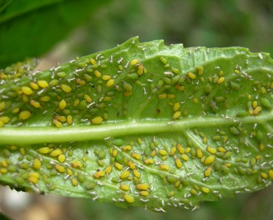

## WHY: Understanding population structure (*Demography*)

- **Central Question: Is population size ↑ ←→ ↓ ?**
- **Age of a population, peak reproductive ages**
- **Frequency of reproduction, reproductive output**
- **Sex ratios determining mating potential**
- **Measuring, predicting, and evaluating population structure/sizes guides decisions**
  - conservation, pest management, harvesting

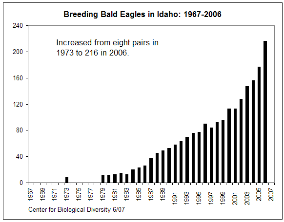

## Case Study: White-tailed deer population size

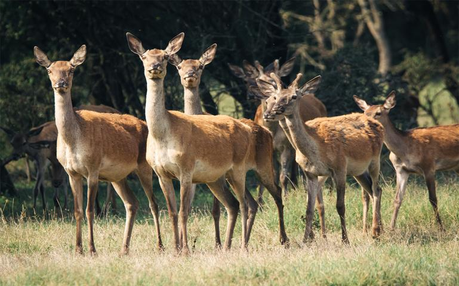

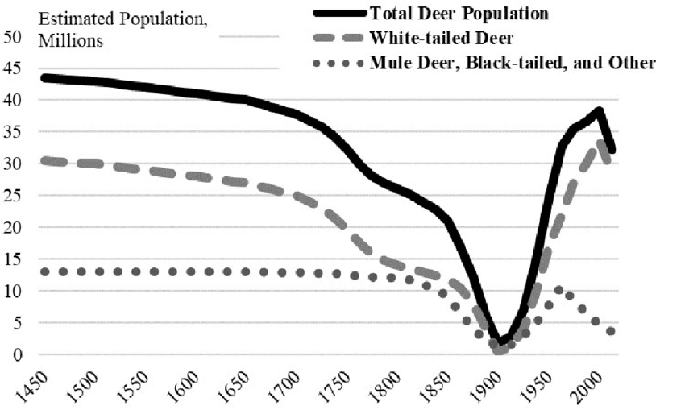

## Case Study: Deer population *density* is super informative

**Hunting regulations, disease vectors, car insurance…**

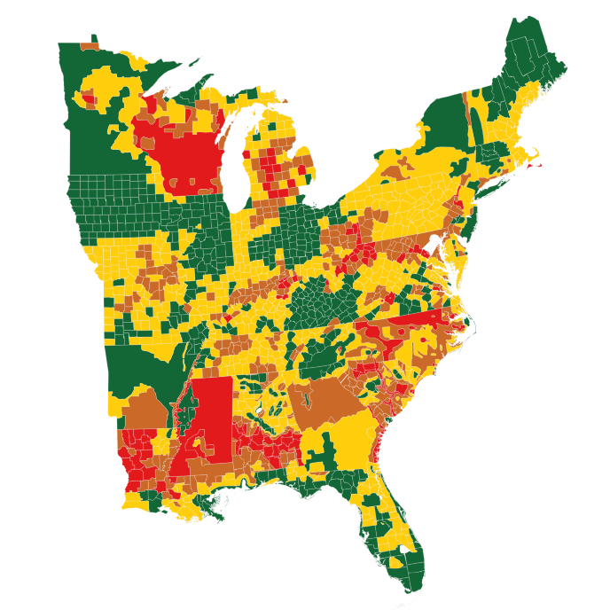

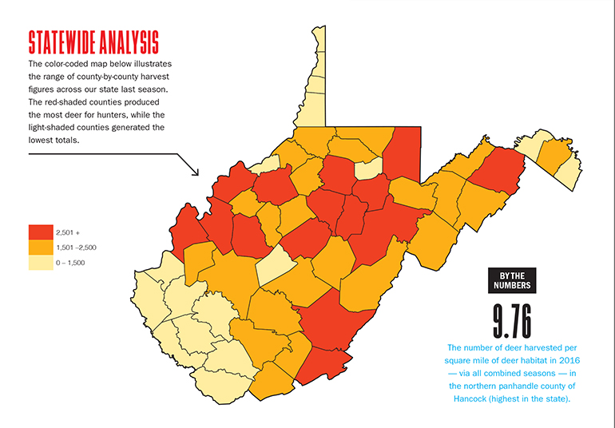

## Case Study: Zombie deer

**Understanding deer density helps predict spread of CWD**

[figure not shown]

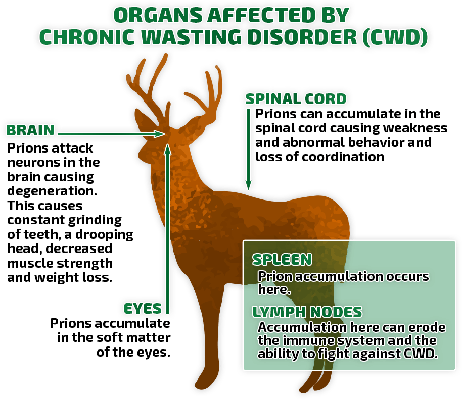

## WHO: Definition of an individual can be tricky

- **Unitary organism: forming a single entity**
  - deer, bird, spider, human, etc.
- **Modular organisms: colonies**
  - bacteria, algae, corals, biofilms
  - certain plants: ferns grow by rhizomes
- **Some modular organisms may themselves be ecological populations**
  - One coral colony contains many connected polyps, and each polyp grows, feeds, reproduces, and dies

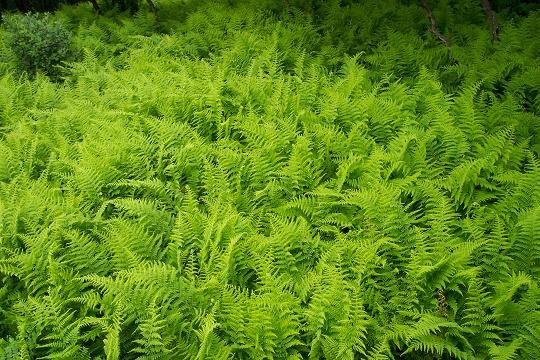

## HOW: Estimates from representative samples

- **Most methods are indirect estimates**
- **Lessons from lab:**
  - census techniques
  - mark & recapture
  - spatial component
  - temporal component

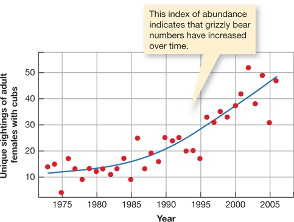

## Populations dynamics: Movement

**Immigration and emigration can change population size even when births and deaths stay the same, making population dynamics harder to interpret.**

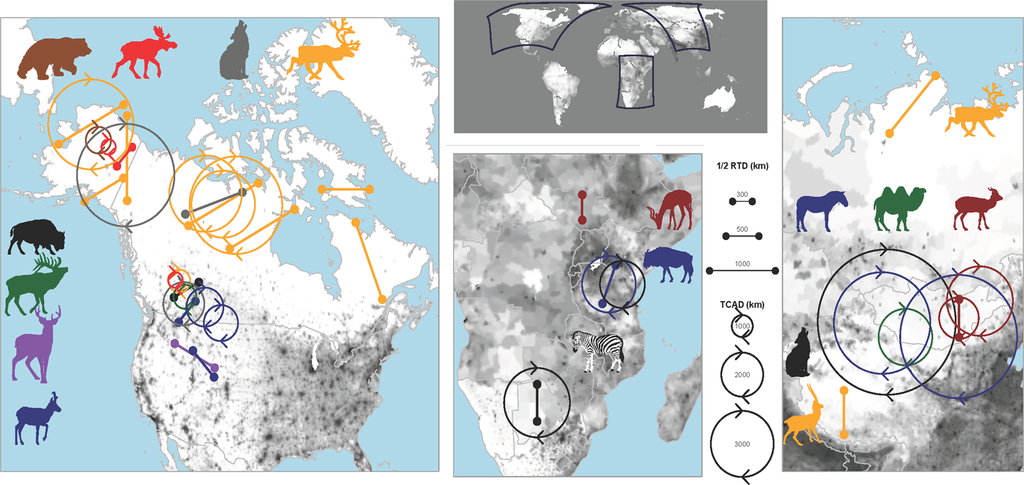

## Life history traits determine reproductive output/timing

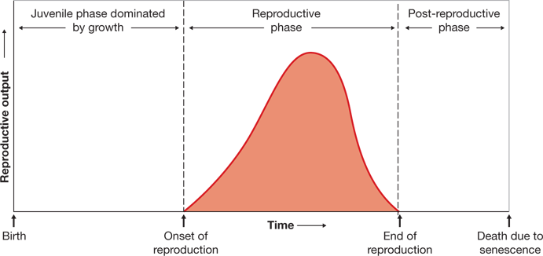

## Life history traits differs vastly across organisms

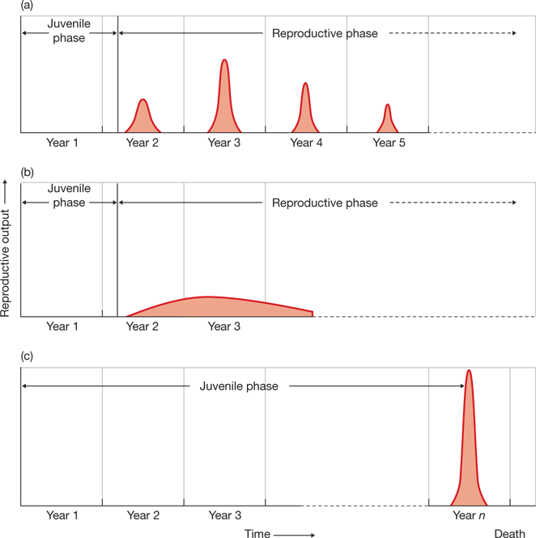

## Life history trait examples: One-off reproduction

**Making offspring is expensive, so reproductive output is a strategy under natural selection**

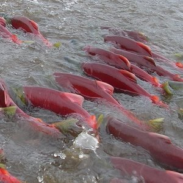

[figure not shown]

## Life history trait examples: Species with short life cycles

**Making offspring is expensive, so reproductive output is a strategy under natural selection**

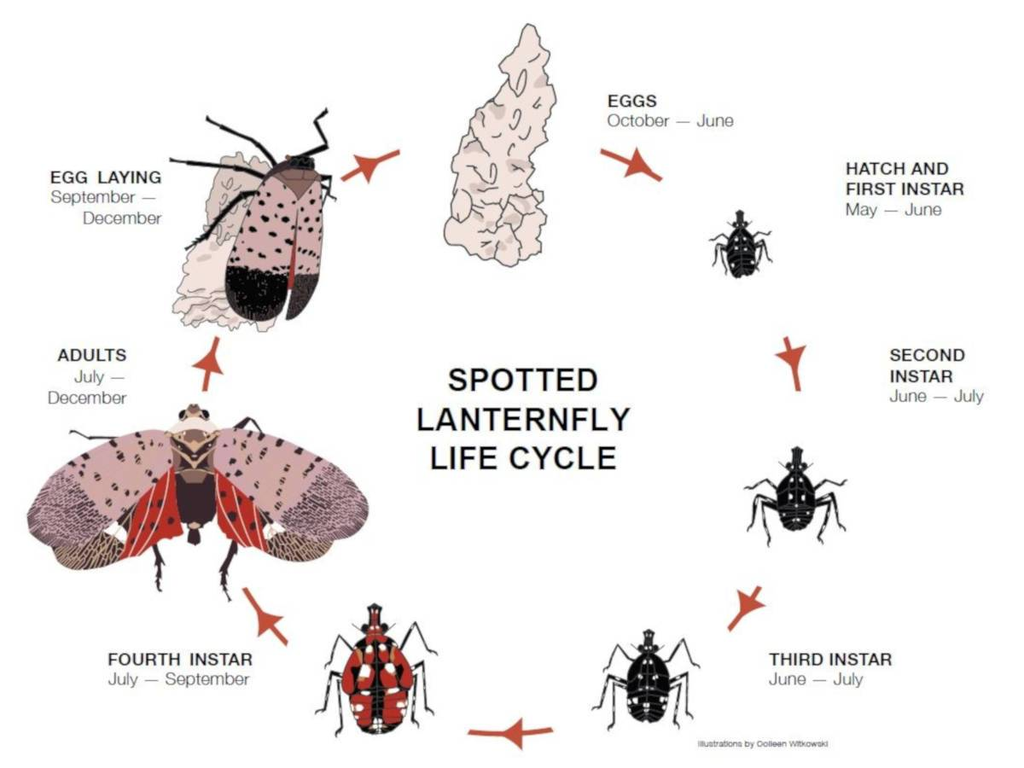

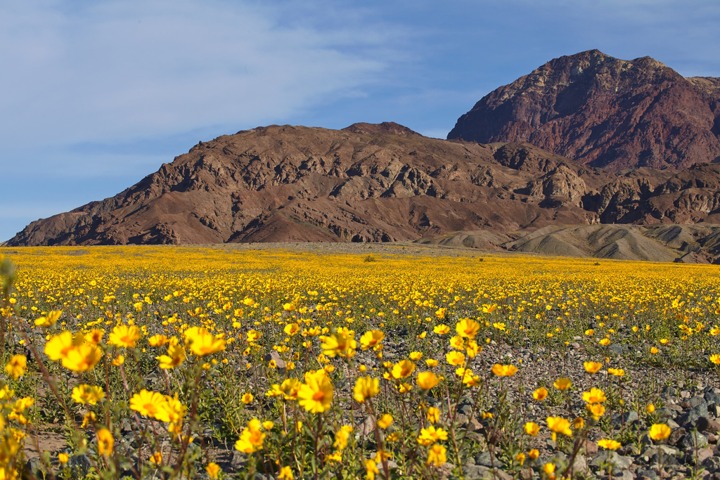

## Life history trait examples: Dormancy

- **Some organisms spend part of their life cycle dormant**
  - seeds, spores, resting eggs, developmental arrest, etc.
- **Dormant individuals can be a large, hidden part of a population**
  - thousands of viable seeds may occur in a square meter of soil
- **Allows individuals to survive unfavorable conditions**
  - some remain dormant for very long times
- **How does this complicate population dynamics?**
  - dormant individuals are easy to miss when estimating population size
  - offspring produce may not enter the next active generation

[figure not shown]

## Life history traits: Reproductive conflict

- **Goal to pass on genes…**
- **When and how to spend your resources**
  - reproduction comes at a cost of growth
  - ↑ flowers + seeds = ↓ leaves and roots
  - are enough resources available to support pregnancy in animals?
  - *surviving vs growing the population is the conflict*
- **Life histories of males and females may differ due to reproductive investment**

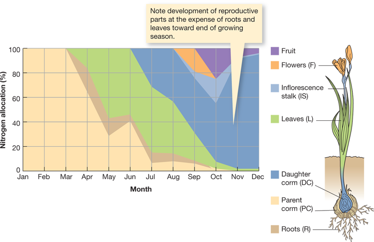

[figure not shown]

- **Populations are composites of individual life histories**
  - who survived from previous year
  - new individuals (births/immigration)
  - survivability of offspring and parents in a year

## Survival and reproduction determine population change

- **Birth rates and survivorship tell us whether a population is likely to grow, shrink, or remain stable**
- **Survival and reproduction differ among ages or life stages**
  - juveniles, reproductive adults, and older individuals contribute differently to population growth
- **Life tables summarize these age-specific patterns**
  - *Cohort*: follow individuals born at the same time through their lives
  - *Static*: compare the ages of individuals present at one point in time
- **These patterns reveal more than population size alone**
  - age structure, when mortality is high, which age contributes the most to population growth, etc.

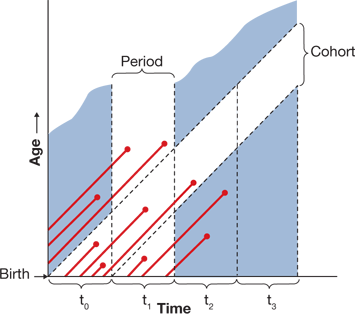

## r/K selection theory: Growth and reproduction strategies

- **r-selected species: “cheap” offspring**
- **K-selected species: “expensive” offspring**
- **These are the 2 ends of a spectrum**

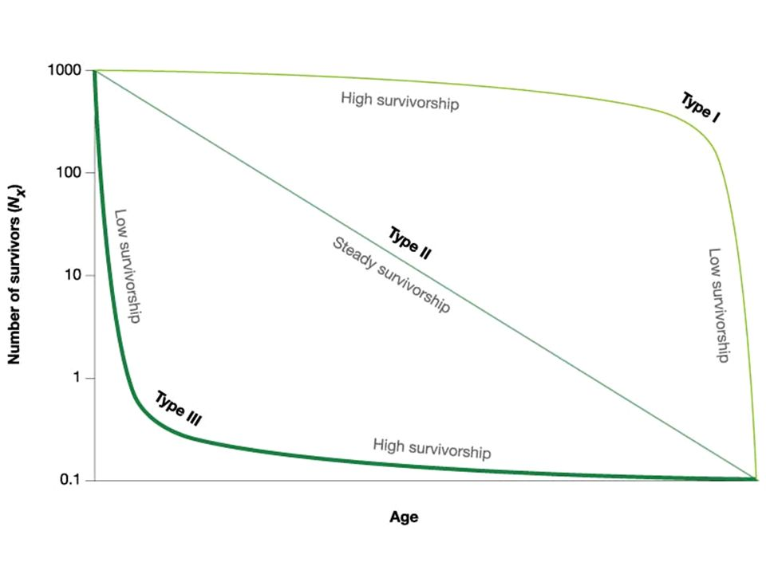

[figure not shown]

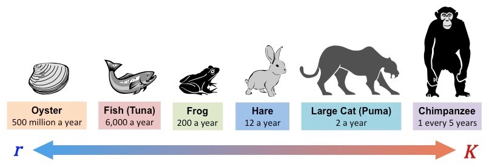

## Populations with unlimited resources: **Exponential growth**

**Population growth that accelerates because a larger population produces more new individuals at constant rates**

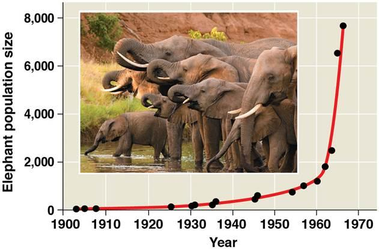

[figure not shown]

## Population growth eventually faces environmental resistance

- **Density-dependent**
  - competition
  - predation
  - disease
  - resources
- **Density-independent**
  - catastrophic events
  - disturbances
- **Carrying Capacity: maximum size of a population an environment can support**
  - environmental resistance leads to **Logistic growth (S-shaped curve)**

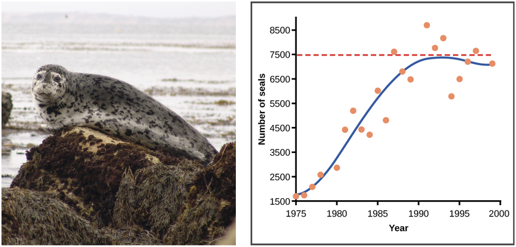

## Testable concepts in this lecture

- **Population structure and measurement**
  - abundance, density, demographics, and population boundaries
- **Population change**
  - births, deaths, immigration, emigration, and demographic structure
- **Life history and survivorship**
  - reproductive strategies, dormancy, survivorship curves, and r/K selection
- **Population growth and environmental limits**
  - exponential vs. logistic growth, environmental resistance, and carrying capacity